# Northampton Tree Planting and Removal 2015-2022

Author

Kent S Johnson

## Introduction

This report summarizes tree plantings and subsequent removals for the City of Northampton in the years 2015 to 2022.

The analysis is based on tree data from the City Tree Warden.

## Summary

In this period, 2,223 trees were planted. Of these, 2,112 (95%) have survived to date and 111 (5%) have been removed.

## Yearly planting and removal

This table and chart show planting and removals by planting year. They count removals against the planting year; the removal numbers for recent years may increase over time as more trees are removed.

Trees planted and subsequently removed 2015-2022

| Year | Total | Removed Pct | Removed Count | Remaining Count |
| --- | --- | --- | --- | --- |
| 2015 | 96 | 0% | 0 | 96 |
| 2016 | 128 | 1% | 1 | 127 |
| 2017 | 248 | 2% | 4 | 244 |
| 2018 | 292 | 9% | 26 | 266 |
| 2019 | 435 | 4% | 17 | 418 |
| 2020 | 244 | 13% | 32 | 212 |
| 2021 | 312 | 8% | 25 | 287 |
| 2022 | 297 | 2% | 6 | 291 |
| 2023 | 171 | 0% | 0 | 171 |
| Total | 2223 | 5% | 111 | 2112 |

Data: Northampton Tree Warden | Analysis: Kent S Johnson

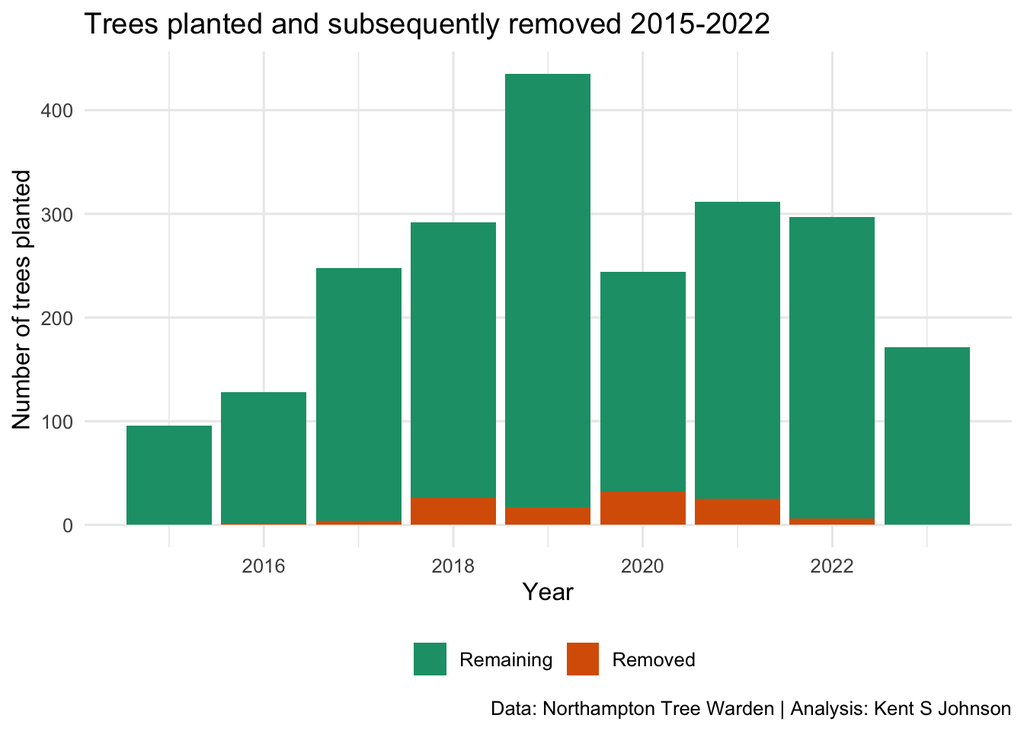

## Top species planted

Tree species planted 2015-2022

Top ten species planted

| Year | Tilia tomentosa | Platanus x acerifolia | Ginkgo biloba | Crataegus viridis | Liquidambar styraciflua | Gleditsia triacanthos | Taxodium distichum | Gymnocladus dioicus | Quercus bicolor | Nyssa sylvatica |
| --- | --- | --- | --- | --- | --- | --- | --- | --- | --- | --- |
| 2015 | 0 | 5 | 1 | 2 | 4 | 0 | 0 | 0 | 8 | 3 |
| 2016 | 0 | 0 | 2 | 0 | 24 | 10 | 0 | 0 | 10 | 0 |
| 2017 | 10 | 10 | 37 | 13 | 21 | 14 | 0 | 3 | 0 | 8 |
| 2018 | 22 | 55 | 45 | 17 | 8 | 21 | 2 | 0 | 0 | 13 |
| 2019 | 40 | 22 | 36 | 40 | 27 | 24 | 30 | 55 | 8 | 6 |
| 2020 | 24 | 22 | 19 | 32 | 4 | 12 | 14 | 0 | 19 | 8 |
| 2021 | 40 | 26 | 20 | 17 | 5 | 8 | 7 | 16 | 25 | 19 |
| 2022 | 30 | 24 | 3 | 17 | 16 | 10 | 15 | 5 | 13 | 7 |
| 2023 | 22 | 12 | 6 | 12 | 15 | 3 | 19 | 6 | 2 | 14 |
| Total | 188 | 176 | 169 | 150 | 124 | 102 | 87 | 85 | 85 | 78 |
| Percent | 8% | 8% | 8% | 7% | 6% | 5% | 4% | 4% | 4% | 4% |

Data: Northampton Tree Warden | Analysis: Kent S Johnson

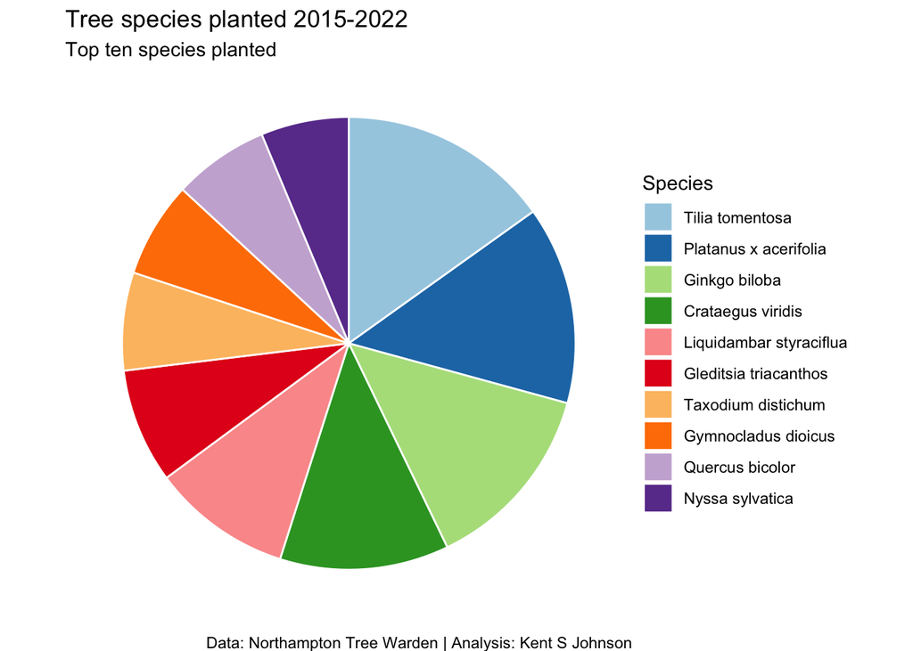

## Change in top species

The percentages of most of the top species in the urban forest have declined as other species have been planted. Of the top ten species, only *Gleditsia triacanthos* shows a small increase in percentage.

A general guideline is that an urban forest should contain no more than 10% of any one species. In the 2015 survey, *Acer rubrum* nearly reached this value, but planting in other families has decreased the percentage of *Acer rubrum* below 10%.

Top species as percent of total urban forest

Top ten species overall

| Species | 2015 Count | 2015 Percent | 2022 Count | 2022 Percent | Change in percent |  |
| --- | --- | --- | --- | --- | --- | --- |
| Acer rubrum | 957 | 10% | 959 | 8% |  | −1.7% |
| Acer saccharum | 887 | 9% | 895 | 8% | −1.5% |  |
| Acer platanoides | 839 | 9% | 839 | 7% | −1.5% |  |
| Pinus strobus | 739 | 8% | 739 | 6% | −1.3% |  |
| Quercus rubra | 504 | 5% | 504 | 4% | −0.9% |  |
| Quercus palustris | 398 | 4% | 410 | 3% | −0.6% |  |
| Gleditsia triacanthos | 248 | 3% | 348 | 3% | 0.4% |  |
| Robinia pseudoacacia | 331 | 3% | 331 | 3% | −0.6% |  |
| Quercus alba | 266 | 3% | 281 | 2% | −0.4% |  |
| Tsuga candensis | 275 | 3% | 275 | 2% | −0.5% |  |

Data: Northampton Tree Warden | Analysis: Kent S Johnson

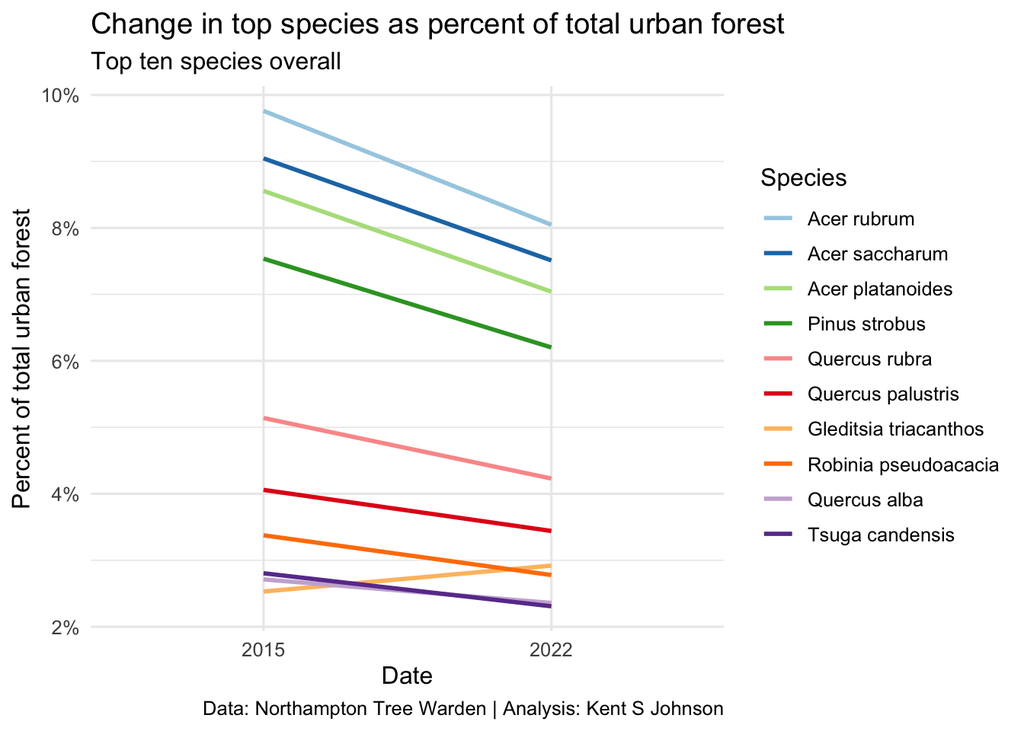

## Survival by species

Species planted and survived 2015-2022

Top ten species planted

| Binomial | Total | Removed Pct | Removed Count | Remaining Pct | Remaining Count |
| --- | --- | --- | --- | --- | --- |
| Liquidambar styraciflua | 124 | 1% | 1 | 99% | 123 |
| Gymnocladus dioicus | 85 | 1% | 1 | 99% | 84 |
| Gleditsia triacanthos | 102 | 2% | 2 | 98% | 100 |
| Crataegus viridis | 150 | 2% | 3 | 98% | 147 |
| Nyssa sylvatica | 78 | 5% | 4 | 95% | 74 |
| Taxodium distichum | 87 | 7% | 6 | 93% | 81 |
| Tilia tomentosa | 188 | 7% | 13 | 93% | 175 |
| Quercus bicolor | 85 | 8% | 7 | 92% | 78 |
| Ginkgo biloba | 169 | 11% | 18 | 89% | 151 |
| Platanus x acerifolia | 176 | 18% | 31 | 82% | 145 |

Data: Northampton Tree Warden | Analysis: Kent S Johnson

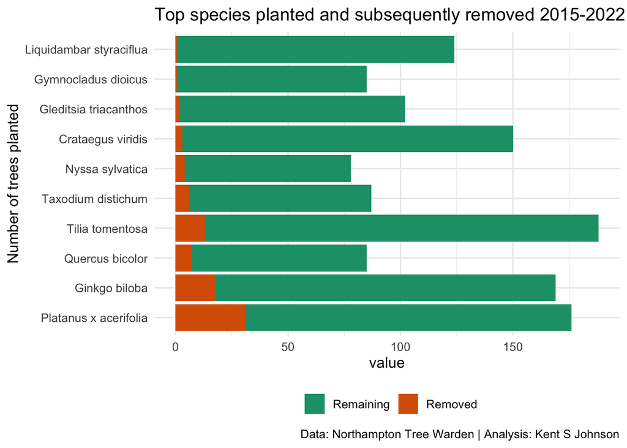

Removal by year, selected species

| Year | Platanus x acerifolia Total | Platanus x acerifolia Removed | Platanus x acerifolia Pct | Quercus bicolor Total | Quercus bicolor Removed | Quercus bicolor Pct | Ginkgo biloba Total | Ginkgo biloba Removed | Ginkgo biloba Pct |
| --- | --- | --- | --- | --- | --- | --- | --- | --- | --- |
| 2015 | 5 | 0 | 0% | 8 | 0 | 0% | 1 | 0 | 0% |
| 2016 | - | - | - | 10 | 0 | 0% | 2 | 0 | 0% |
| 2017 | 10 | 0 | 0% | - | - | - | 37 | 0 | 0% |
| 2018 | 55 | 11 | 20% | - | - | - | 45 | 7 | 16% |
| 2019 | 22 | 2 | 9% | 8 | 0 | 0% | 36 | 4 | 11% |
| 2020 | 22 | 10 | 45% | 19 | 1 | 5% | 19 | 5 | 26% |
| 2021 | 26 | 8 | 31% | 25 | 3 | 12% | 20 | 0 | 0% |
| 2022 | 24 | 0 | 0% | 13 | 3 | 23% | 3 | 2 | 67% |
| 2023 | 12 | 0 | 0% | 2 | 0 | 0% | 6 | 0 | 0% |
| Total | 176 | 31 | 18% | 85 | 7 | 8% | 169 | 18 | 11% |

Data: Northampton Tree Warden | Analysis: Kent S Johnson

## Top genera planted

Tree genera planted 2015-2022

Top ten genera planted

| Year | Tilia | Platanus | Ginkgo | Quercus | Crataegus | Liquidambar | Gleditsia | Taxodium | Gymnocladus | Ulmus |
| --- | --- | --- | --- | --- | --- | --- | --- | --- | --- | --- |
| 2015 | 3 | 10 | 1 | 9 | 2 | 4 | 0 | 0 | 0 | 5 |
| 2016 | 6 | 0 | 2 | 20 | 0 | 24 | 10 | 0 | 0 | 15 |
| 2017 | 11 | 10 | 37 | 11 | 13 | 21 | 14 | 0 | 3 | 0 |
| 2018 | 43 | 55 | 45 | 14 | 17 | 8 | 21 | 2 | 0 | 6 |
| 2019 | 53 | 22 | 36 | 8 | 40 | 27 | 24 | 30 | 55 | 17 |
| 2020 | 24 | 22 | 19 | 27 | 32 | 4 | 12 | 14 | 0 | 7 |
| 2021 | 40 | 26 | 20 | 37 | 17 | 5 | 8 | 7 | 16 | 10 |
| 2022 | 30 | 24 | 3 | 38 | 17 | 16 | 10 | 15 | 5 | 20 |
| 2023 | 22 | 12 | 6 | 2 | 12 | 15 | 3 | 19 | 6 | 3 |
| Total | 232 | 181 | 169 | 166 | 150 | 124 | 102 | 87 | 85 | 83 |
| Percent | 10% | 8% | 8% | 7% | 7% | 6% | 5% | 4% | 4% | 4% |

Data: Northampton Tree Warden | Analysis: Kent S Johnson

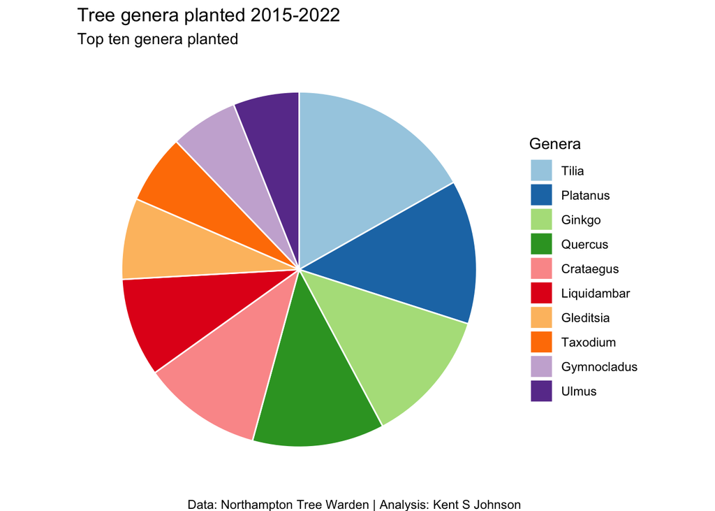

## Change in top genera

The percentages of genus *Acer*, *Pinus* and *Picea* in the urban forest have declined as other genera have been planted. The percentage of *Quercus* has only declined slightly because many were planted. *Tilia* shows the greatest increase in percentage.

A general guideline is that an urban forest should contain no more than 20% of any one genus. *Acer* is the only genus in Northampton that exceeds this value.

Top genera as percent of total urban forest

Top ten genera overall

| Genus | 2015 Count | 2015 Percent | 2022 Count | 2022 Percent | Change in percent |  |
| --- | --- | --- | --- | --- | --- | --- |
| Acer | 3,032 | 31% | 3,047 | 26% |  | −5.4% |
| Quercus | 1,262 | 13% | 1,416 | 12% | −1.0% |  |
| Pinus | 798 | 8% | 798 | 7% | −1.4% |  |
| Prunus | 340 | 3% | 410 | 3% | −0.0% |  |
| Tilia | 182 | 2% | 399 | 3% | 1.5% |  |
| Picea | 393 | 4% | 393 | 3% | −0.7% |  |
| Ulmus | 291 | 3% | 374 | 3% | 0.2% |  |
| Gleditsia | 248 | 3% | 348 | 3% | 0.4% |  |
| Fraxinus | 331 | 3% | 331 | 3% | −0.6% |  |
| Robinia | 331 | 3% | 331 | 3% | −0.6% |  |

Data: Northampton Tree Warden | Analysis: Kent S Johnson

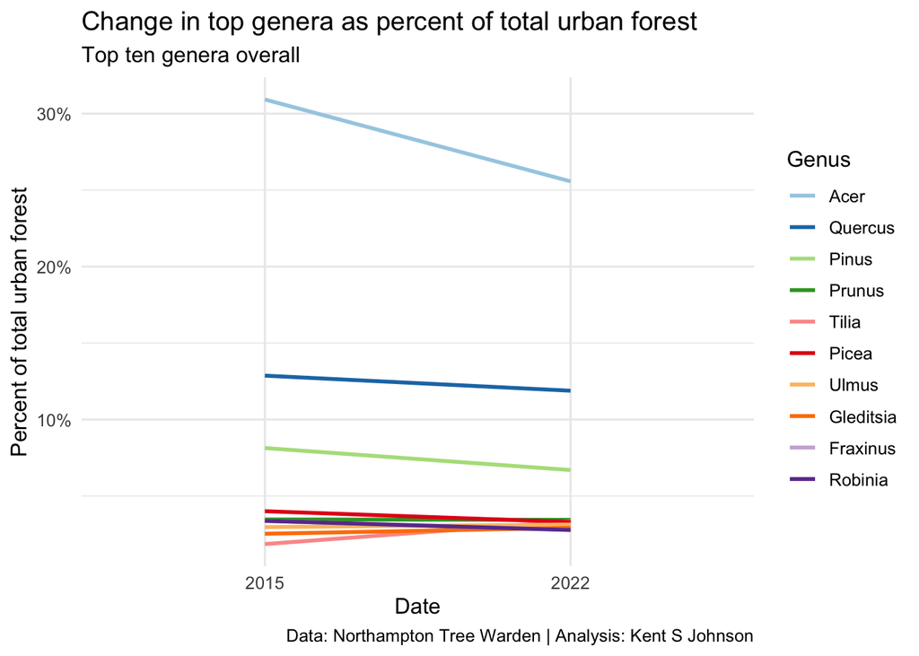

## Top families planted

Tree families planted 2015-2022

Top ten families planted

| Year | Fabaceae | Rosaceae | Malvaceae | Fagaceae | Platanaceae | Ginkgoaceae | Altingiaceae | Cupressaceae | Betulaceae | Ulmaceae |
| --- | --- | --- | --- | --- | --- | --- | --- | --- | --- | --- |
| 2015 | 0 | 29 | 3 | 9 | 10 | 1 | 4 | 0 | 24 | 5 |
| 2016 | 18 | 2 | 6 | 20 | 0 | 2 | 24 | 0 | 12 | 15 |
| 2017 | 35 | 47 | 11 | 26 | 10 | 37 | 21 | 4 | 28 | 0 |
| 2018 | 35 | 45 | 43 | 23 | 55 | 45 | 8 | 9 | 1 | 6 |
| 2019 | 129 | 63 | 53 | 8 | 22 | 36 | 27 | 30 | 19 | 18 |
| 2020 | 17 | 53 | 24 | 27 | 22 | 19 | 4 | 14 | 0 | 7 |
| 2021 | 45 | 30 | 40 | 37 | 26 | 20 | 5 | 19 | 10 | 10 |
| 2022 | 29 | 56 | 30 | 41 | 24 | 3 | 16 | 15 | 13 | 31 |
| 2023 | 34 | 17 | 22 | 2 | 12 | 6 | 15 | 31 | 2 | 3 |
| Total | 342 | 342 | 232 | 193 | 181 | 169 | 124 | 122 | 109 | 95 |
| Percent | 15% | 15% | 10% | 9% | 8% | 8% | 6% | 5% | 5% | 4% |

Data: Northampton Tree Warden | Analysis: Kent S Johnson

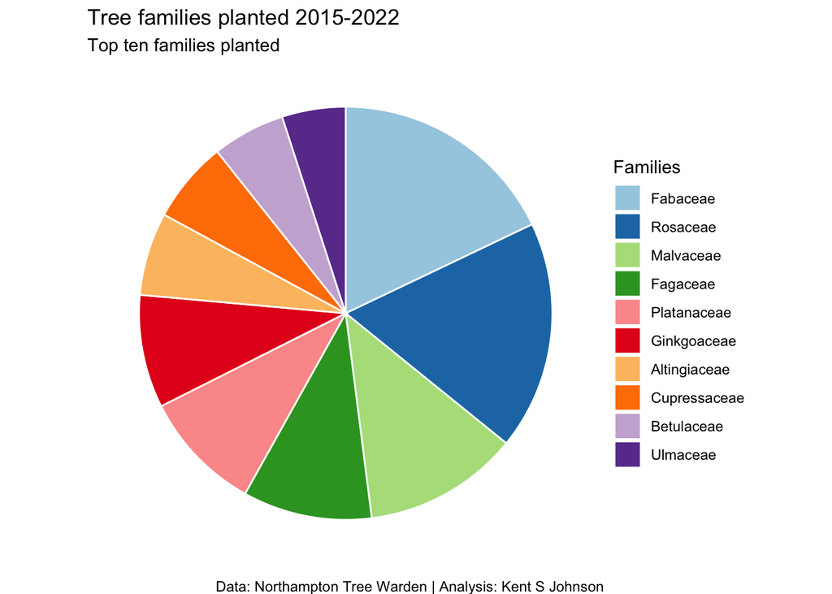

## Change in top families

The percentages of families *Sapindaceae* and *Pinaceae* in the urban forest have declined as other families have been planted. The percentage of *Fagaceae* has not changed much because many were planted. The percentages of *Rosaceae*, *Fabaceae* and *Malvaceae* have increased due to significant numbers of new plantings.

A general guideline is that an urban forest should contain no more than 30% of any one family. In the 2015 survey, *Sapindaceae* exceeded this value, but planting in other families has decreased the percentage of *Sapindaceae* below 30%.

Top families as percent of total urban forest

Top ten families overall

| Family | 2015 Count | 2015 Percent | 2022 Count | 2022 Percent | Change in percent |  |
| --- | --- | --- | --- | --- | --- | --- |
| Sapindaceae | 3,050 | 31% | 3,075 | 26% |  | −5.3% |
| Pinaceae | 1,520 | 16% | 1,520 | 13% | −2.7% |  |
| Fagaceae | 1,306 | 13% | 1,487 | 12% | −0.8% |  |
| Rosaceae | 778 | 8% | 1,115 | 9% | 1.4% |  |
| Fabaceae | 653 | 7% | 989 | 8% | 1.6% |  |
| Cupressaceae | 408 | 4% | 524 | 4% | 0.2% |  |
| Ulmaceae | 306 | 3% | 401 | 3% | 0.2% |  |
| Malvaceae | 182 | 2% | 399 | 3% | 1.5% |  |
| Oleaceae | 351 | 4% | 378 | 3% | −0.4% |  |
| Betulaceae | 245 | 2% | 351 | 3% | 0.4% |  |

Data: Northampton Tree Warden | Analysis: Kent S Johnson

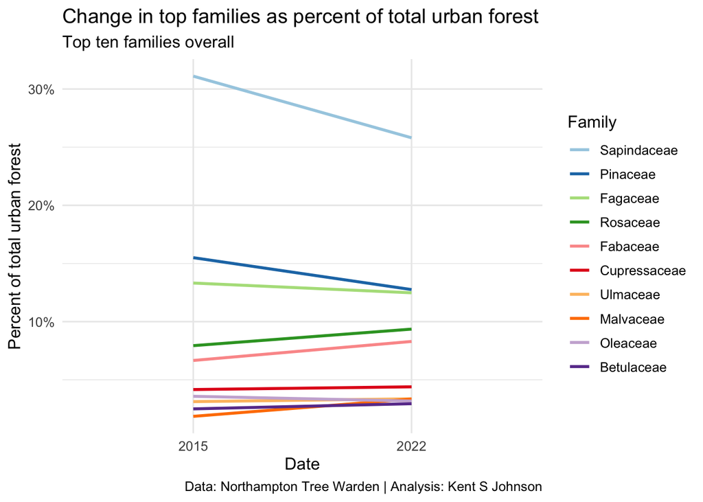

## Planting by sapling type

Trees planted by sapling type

| Year | Grow Bag | Bare Root | Unknown | B & B | Container |
| --- | --- | --- | --- | --- | --- |
| 2015 | 96 | 0 | 0 | 0 | 0 |
| 2016 | 123 | 4 | 1 | 0 | 0 |
| 2017 | 196 | 0 | 4 | 40 | 8 |
| 2018 | 193 | 46 | 26 | 21 | 6 |
| 2019 | 275 | 100 | 17 | 42 | 1 |
| 2020 | 145 | 67 | 32 | 0 | 0 |
| 2021 | 203 | 68 | 25 | 15 | 1 |
| 2022 | 151 | 56 | 6 | 84 | 0 |
| 2023 | 170 | 0 | 0 | 1 | 0 |
| Total | 1552 | 341 | 111 | 203 | 16 |

Data: Northampton Tree Warden | Analysis: Kent S Johnson

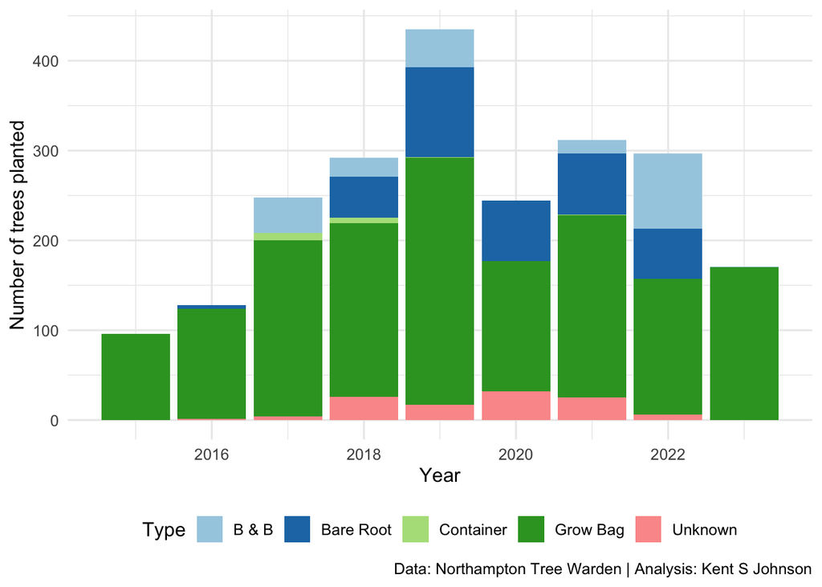

## Planting by ward

This table summarizes the number of trees planted by ward.

Trees planted by ward

| Year | Ward 1 | Ward 2 | Ward 3 | Ward 4 | Ward 5 | Ward 6 | Ward 7 | Ward Unknown |
| --- | --- | --- | --- | --- | --- | --- | --- | --- |
| 2015 | 11 | 14 | 31 | 25 | 4 | 5 | 6 | 0 |
| 2016 | 4 | 26 | 46 | 14 | 5 | 9 | 23 | 1 |
| 2017 | 32 | 42 | 52 | 75 | 21 | 7 | 15 | 4 |
| 2018 | 18 | 11 | 136 | 17 | 42 | 14 | 28 | 26 |
| 2019 | 93 | 47 | 94 | 14 | 65 | 55 | 50 | 17 |
| 2020 | 9 | 56 | 14 | 13 | 66 | 25 | 29 | 32 |
| 2021 | 50 | 36 | 52 | 64 | 23 | 33 | 29 | 25 |
| 2022 | 82 | 43 | 47 | 45 | 11 | 26 | 37 | 6 |
| 2023 | 25 | 23 | 29 | 11 | 25 | 0 | 58 | 0 |
| Total | 324 | 298 | 501 | 278 | 262 | 174 | 275 | 111 |

Data: Northampton Tree Warden | Analysis: Kent S Johnson

## Planting in Environmental Justice communities

Northampton includes seven 2020 Census block groups which are classified as Environmental Justice populations - four with substantial minority populations and three with both minority and low-income populations.

This table shows the number of trees planted each year in Environmental Justice communities of Northampton.

Trees planted in Environmental Justice communities

| Year | Count |
| --- | --- |
| 2015 | 39 |
| 2016 | 22 |
| 2017 | 78 |
| 2018 | 64 |
| 2019 | 96 |
| 2020 | 31 |
| 2021 | 147 |
| 2022 | 108 |
| 2023 | 58 |
| Total | 643 |

Data: Northampton Tree Warden | Analysis: Kent S Johnson

## Planting in special projects

Some trees have been planted as part of dedicated projects such as Arbor Week and neighborhood plantings. This table summarizes special project plantings.

Trees planted in special projects

| Year | South St | Arbor Week | Neighborhood | Cooley Dickenson Hosp. | B'nai Israel | Rotary Club |
| --- | --- | --- | --- | --- | --- | --- |
| 2017 | 65 | - | - | - | - | - |
| 2018 | - | 2 | 17 | - | - | - |
| 2019 | - | 54 | 54 | - | - | - |
| 2020 | - | - | 10 | 22 | - | - |
| 2021 | - | 48 | 42 | - | - | - |
| 2022 | - | 30 | - | - | 11 | 38 |
| 2023 | - | 31 | - | - | - | - |
| Total | 65 | 165 | 123 | 22 | 11 | 38 |

Data: Northampton Tree Warden | Analysis: Kent S Johnson

## Planting location description

The trees planted are predominantly in the tree belt and right-of-way (67%) and set back (20%) with 12% in other locations.

Planting locations 2015-2022

| Year | Tree belt | Set back | Right of way | Set back with agreement | Unknown | Cemetery | City park | School | Parking lot | Borderline | Conservation area |
| --- | --- | --- | --- | --- | --- | --- | --- | --- | --- | --- | --- |
| 2015 | 96 | 0 | 0 | 0 | 0 | 0 | 0 | 0 | 0 | 0 | 0 |
| 2016 | 43 | 84 | 0 | 0 | 1 | 0 | 0 | 0 | 0 | 0 | 0 |
| 2017 | 144 | 85 | 0 | 0 | 4 | 8 | 4 | 0 | 0 | 0 | 3 |
| 2018 | 219 | 7 | 11 | 11 | 26 | 9 | 9 | 0 | 0 | 0 | 0 |
| 2019 | 270 | 26 | 38 | 83 | 17 | 0 | 0 | 0 | 0 | 1 | 0 |
| 2020 | 115 | 12 | 47 | 29 | 32 | 0 | 0 | 0 | 9 | 0 | 0 |
| 2021 | 175 | 18 | 43 | 29 | 25 | 16 | 0 | 0 | 1 | 5 | 0 |
| 2022 | 168 | 18 | 20 | 16 | 6 | 14 | 18 | 37 | 0 | 0 | 0 |
| 2023 | 62 | 20 | 29 | 14 | 0 | 22 | 15 | 9 | 0 | 0 | 0 |
| Total | 1292 | 270 | 188 | 182 | 111 | 69 | 46 | 46 | 10 | 6 | 3 |

Data: Northampton Tree Warden | Analysis: Kent S Johnson

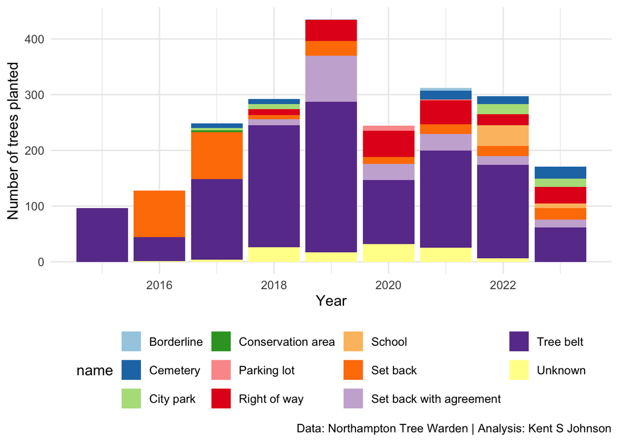

## Planting map

This map shows the approximate locations of the 2,112 surviving trees. Overlays show Northampton wards and Environmental Justice (EJ) communities.

Mouse-over trees for additional information.

[interactive chart not shown]